# HW23

Esat Canli

07/05/2020

Introduction: Electric Usage Rates in MwH in Turkey will be examined in this analysis. Data will be read, processed, and also needs tidying. xts and ts objects will be used for manipulation along with data.table package,

Base R functions in plottin will be generally used with some ggplot uses time to time. XTS objects are used to convert the time-based data into different formats while maintaining it’s specifications.

xts objects also proves an ease of use in performing aggregation and date operations.

Initial Ideas: Electricity consumption should have weekly (each 7 day) and also seasonal reversions to the previous values. Also, 24 hour reversion may be observed.

Purpose: Electric Consumption Data is a highly seasonal data with daily, weekly, monthly properties and also exhibits strange drops and increases resulting from special days like holidays. The purpose of this analysis is to forecast the next 24 hours of electricity consumption in Turkey based on historic data.

Challenges: Novel coronavirus has impacted the electric usage in homes severly in the last 2 months, therefore our predictions are likely to be higher than what we would have made without the virus, Also, the data inherently posesses some strange properties such as different number of days in a month or a fractional number of weeks in a month, this problem will be adressed later.

Loading Neccessary Packages

```r
require(readxl)
require(data.table)
require(zoo)
require(xts)
require(forecast)
require(stats)
require(lubridate)
require(dplyr)
require(ggplot2)
require(scales)
```

Reading Data from CSV & Adding a Date&Hour Column for ease of use later

```r
Electric_Usage_Data<-read.csv('GercekZamanliTuketim-01012016-26042020.csv',header = T)
head(Electric_Usage_Data)
```

```
##        Tarih     Saat Tüketim.Miktarý..MWh.
## 1 01.01.2016 00:00:00               2627724
## 2 01.01.2016 01:00:00               2499182
## 3 01.01.2016 02:00:00               2353261
## 4 01.01.2016 03:00:00               2246478
## 5 01.01.2016 04:00:00               2200291
## 6 01.01.2016 05:00:00               2195708
```

```r
Electric_Usage_Data$Date<-paste(Electric_Usage_Data$Tarih,Electric_Usage_Data$Saat)
```

Setting Names and Checking the String

```r
names<-c("Date","Hour","Usage(MwH)","Date&Hour")
setnames(x = Electric_Usage_Data,old = names(Electric_Usage_Data),new = names)
str(Electric_Usage_Data)
```

```
## 'data.frame':    37848 obs. of  4 variables:
##  $ Date      : Factor w/ 1577 levels "01.01.2016","01.01.2017",..: 1 1 1 1 1 1 1 1 1 1 ...
##  $ Hour      : Factor w/ 24 levels "00:00:00","01:00:00",..: 1 2 3 4 5 6 7 8 9 10 ...
##  $ Usage(MwH): int  2627724 2499182 2353261 2246478 2200291 2195708 2220354 2184416 2309473 2520227 ...
##  $ Date&Hour : chr  "01.01.2016 00:00:00" "01.01.2016 01:00:00" "01.01.2016 02:00:00" "01.01.2016 03:00:00" ...
```

Converting String to appropriate levels

```r
Electric_Usage_Data$`Usage(MwH)`<-as.numeric(Electric_Usage_Data$`Usage(MwH)`)
str(Electric_Usage_Data)
```

```
## 'data.frame':    37848 obs. of  4 variables:
##  $ Date      : Factor w/ 1577 levels "01.01.2016","01.01.2017",..: 1 1 1 1 1 1 1 1 1 1 ...
##  $ Hour      : Factor w/ 24 levels "00:00:00","01:00:00",..: 1 2 3 4 5 6 7 8 9 10 ...
##  $ Usage(MwH): num  2627724 2499182 2353261 2246478 2200291 ...
##  $ Date&Hour : chr  "01.01.2016 00:00:00" "01.01.2016 01:00:00" "01.01.2016 02:00:00" "01.01.2016 03:00:00" ...
```

Converting to XTS, This is done to perform operations easier when dealing with time related manipulations. Also the Date&Hour column was added so that we can easily convert the data into an xts

```r
Electric_Usage_XTS_Hourly<-xts(Electric_Usage_Data$`Usage(MwH)`,
                               order.by=as.Date(Electric_Usage_Data$`Date&Hour`,"%d.%m.%Y %H:%M:%S"))
```

Checking the Data, if done correctly we should have the correct number of months and days.

```r
nmonths(Electric_Usage_XTS_Hourly)
```

```
## [1] 52
```

```r
ndays(Electric_Usage_XTS_Hourly)
```

```
## [1] 1577
```

Hourly Conversion

Since the original period of the data is hourly we need a frequency that will fit the it, since we are claiming that there is a period of 24 for each day, we should convert it using the frequency set to 24, basically telling R we have an approximate periodicity of 24 hours in the feeded data

```r
Electric_Usage_TS_Hourly<-ts(Electric_Usage_XTS_Hourly,start=c(2016,1),freq=24)
```

Checking the data

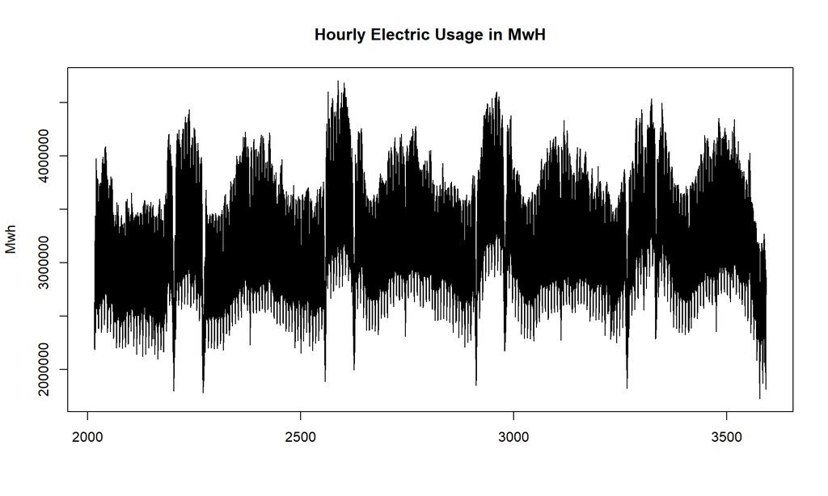

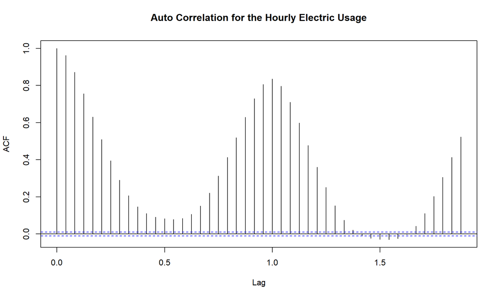

```r
ts.plot(Electric_Usage_TS_Hourly,main="Hourly Electric Usage in MwH", ylab="Mwh", xlab="")
acf(Electric_Usage_TS_Hourly,main="Auto Correlation for the Hourly Electric Usage")
```

Figure 1&2 : Series & Auto-Correlation Plots for 24 hours frequency. Comments: From the first look it, counting bars from the ACF, it can be said that there is a correlation between the 1st and 25th value, as we can understand the same hour of the day will have a correlation throughout the train period.

Hourly Decompostion, we will use both methods until one is proven to be better than the other

```r
Electric_Usage_TS_Hourly_Multiplicative<-decompose(Electric_Usage_TS_Hourly,type="multiplicative")
Electric_Usage_TS_Hourly_Additive<-decompose(Electric_Usage_TS_Hourly,type="additive")
```

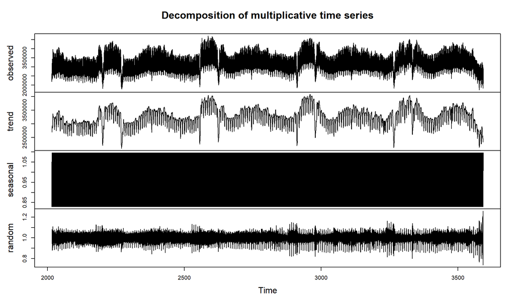

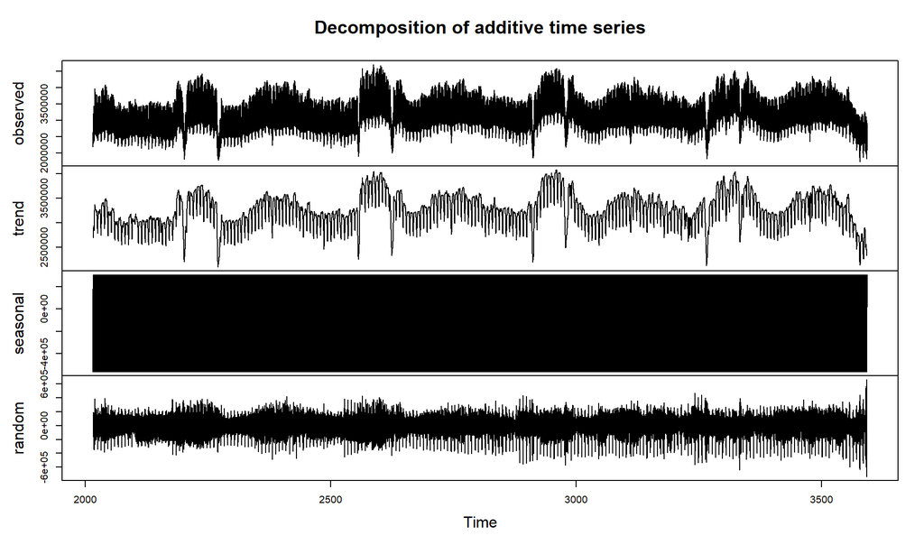

```r
plot(Electric_Usage_TS_Hourly_Multiplicative)
plot(Electric_Usage_TS_Hourly_Additive)
```

Figure 3&4: Hourly Decomposition for Multiplicative and Additive Data Comments: From the first look - as the data set is too large - it may not be useful to make a deduction, let us plot the randomness part of these figures and find out which one serves us better. It should be also stated that we do not have an ever increasing data in our hands, also the sudden decrease in the last period shows that we have a gap in the data since we dont have the full year.

Plotting Randomness of the two, deciding which is a better approximation.

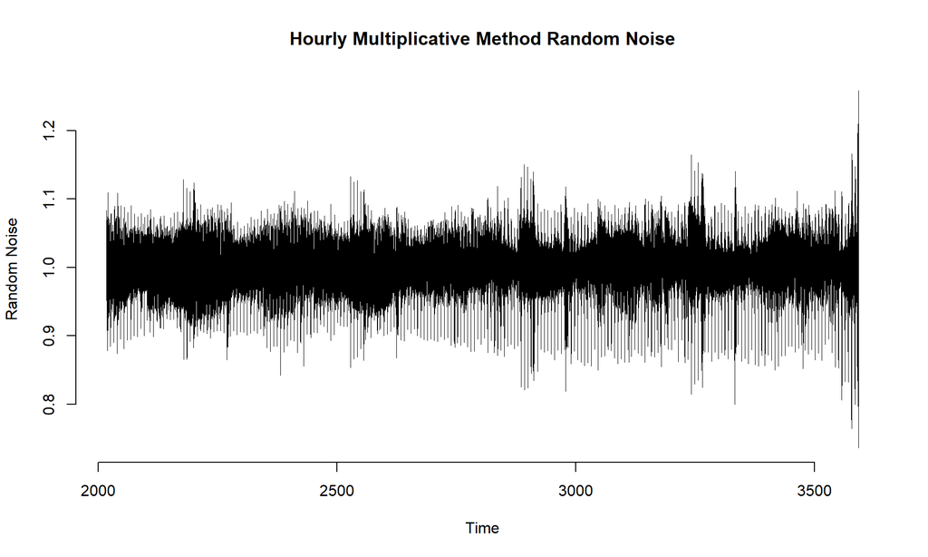

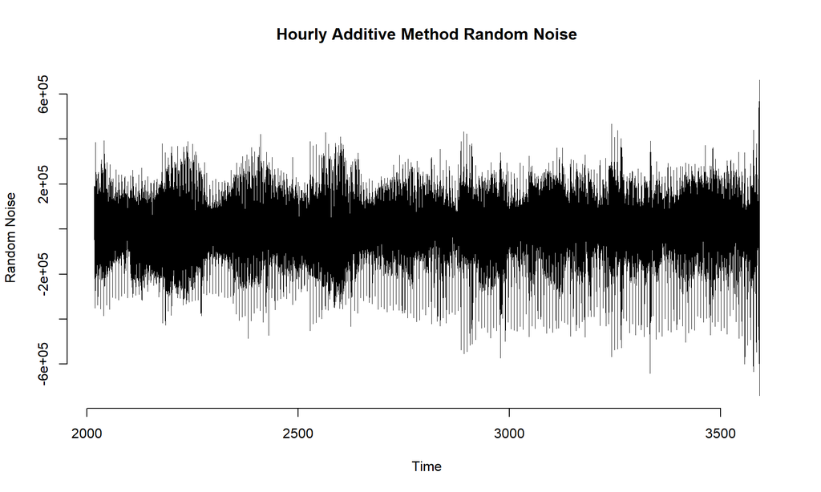

```r
plot(Electric_Usage_TS_Hourly_Multiplicative$random,
     frame=FALSE,
     col="black",
     lwd=0.1,
     main="Hourly Multiplicative Method Random Noise",
     ylab= "Random Noise",
     xlab= "Time")
plot(Electric_Usage_TS_Hourly_Additive$random,
     frame=FALSE,
     col="black",
     lwd=0.1,
     main="Hourly Additive Method Random Noise",
     ylab= "Random Noise",
     xlab= "Time")
```

Figure 5&6: Hourly Multiplicative and Additive Data Randomness Comments: The second graph looks more appropriate for the data since it’s variance does not fluctuate over time, it moves on a random walk with mean remaining constant.

Daily Conversion is done on the mean Since the sum values could have been used, however it would prove hard to have a meaningful result - not comparison - since we can only see the aggreagate sum of hourly values but not the change of the mean of values in consecutive days, I am more interested in how the values change in consecutive days.

using XTS objects: Aggregating all 24 hours of the data and taking a simple mean on the observations, using FUN=mean while seperating the data on the “days” with endpoints later to be aggregated in the mean, periodicity also seems to be correct.

```r
eu_daily<-endpoints(Electric_Usage_XTS_Hourly,on="days")
Electric_Usage_XTS_Daily<-period.apply(Electric_Usage_XTS_Hourly,INDEX=eu_daily,FUN=mean)
periodicity(Electric_Usage_XTS_Daily)
```

```
## Daily periodicity from 2016-01-01 to 2020-04-26
```

Converting back to time series, since now we have a daily data, our new observations are done daily, therefore frequency should be decided on how many days are there in a year, frequency is taken as 7 when converting to a time series object. Because we are naturally claiming that the value of the consumption for today will be similar to the consumption done next week in the same day. All the other decompositions will be done the same way.

```r
Electric_Usage_TS_Daily<-ts(Electric_Usage_XTS_Daily,start=c(2016,1),frequency = 7)
length(Electric_Usage_TS_Daily)
```

```
## [1] 1577
```

Length seems reasonable since we would expect approximately 1577 days in approcimately 4 years of data.

Plotting the data.

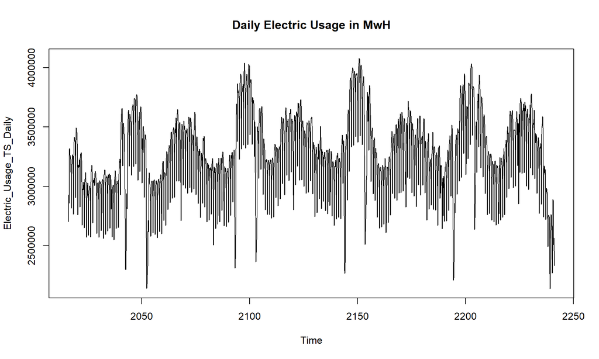

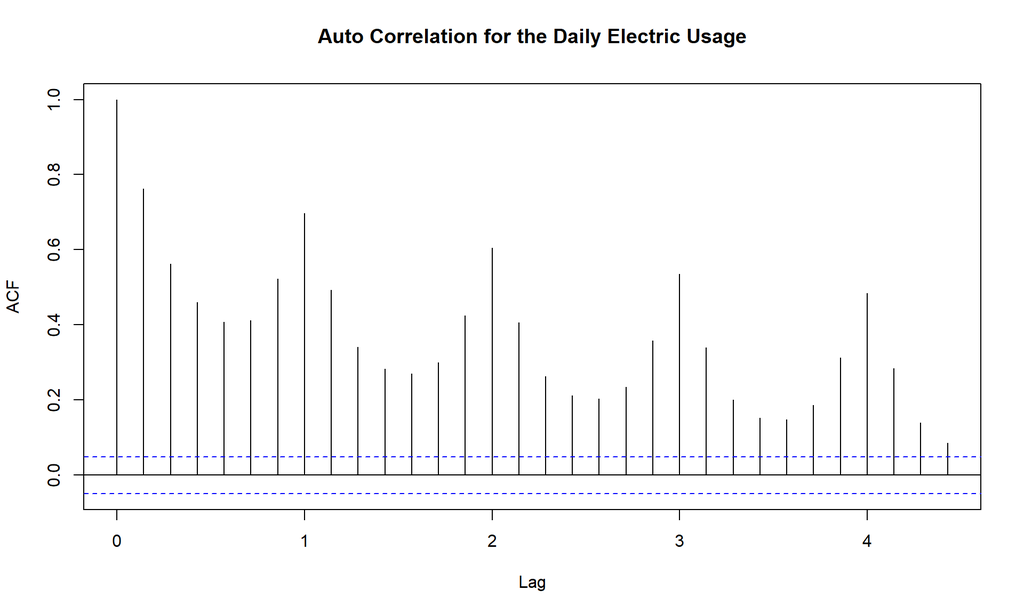

```r
ts.plot(Electric_Usage_TS_Daily, main="Daily Electric Usage in MwH")
acf(Electric_Usage_TS_Daily,main="Auto Correlation for the Daily Electric Usage")
```

Figure 7&8: Series & Auto-Correlation Plots for Daily Frequency Comments: We can clearly see a 7 bar correlation which corresponds to lag 1, therefore we have proven that we also have weekly (7 days) reversion to previous values.

Decomposing the data on days setting with two methods

```r
Electric_Usage_TS_Daily_Multiplicative<-decompose(Electric_Usage_TS_Daily,type="multiplicative")
Electric_Usage_TS_Daily_Additive<-decompose(Electric_Usage_TS_Daily,type="additive")
```

Checking Seasonality and Also Trends

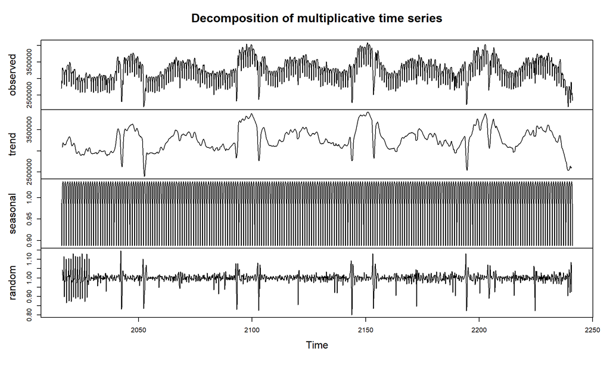

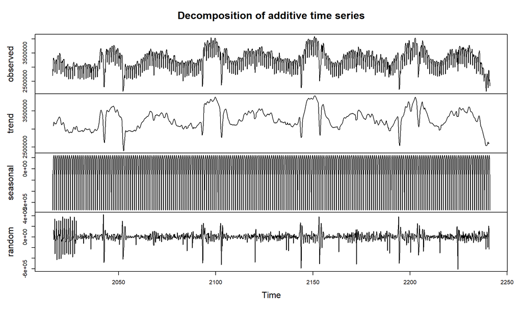

```r
plot(Electric_Usage_TS_Daily_Multiplicative)
plot(Electric_Usage_TS_Daily_Additive)
```

Figure 9&10 : Daily Decomposition for Multiplicative and Additive Data Comments: Daily Usage also shows a non increasing ( no need to take the log) trend with consecutive seasonality and also randomness of the two series are close

Looking at the daily randomness of decomposition

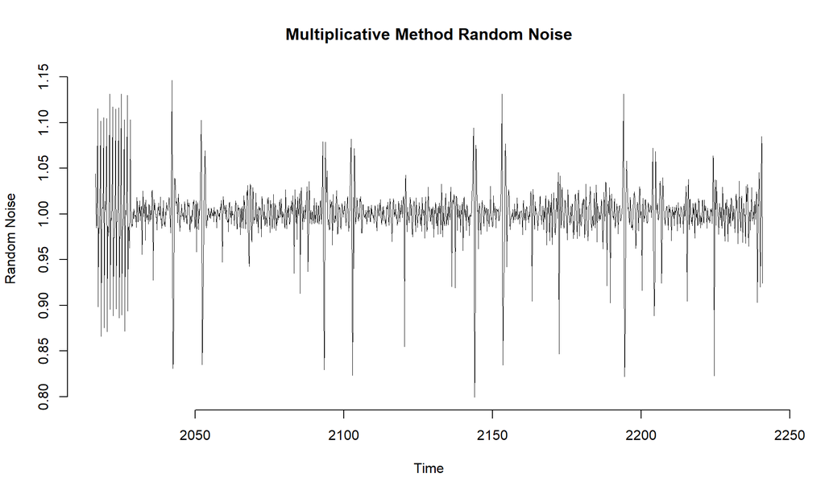

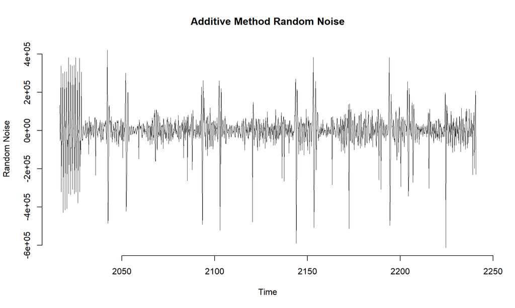

```r
plot(Electric_Usage_TS_Daily_Multiplicative$random,
     frame=FALSE,
     col="black",
     lwd=0.1,
     main="Multiplicative Method Random Noise",
     ylab= "Random Noise",
     xlab= "Time")
# Let's get a closer look into randomness
plot(Electric_Usage_TS_Daily_Additive$random,
     frame=FALSE,
     col="black",
     lwd=0.1,
     main="Additive Method Random Noise",
     ylab= "Random Noise",
     xlab= "Time")
```

Figure 11&12: Daily Multiplicative and Additive Data Randomness Comments: Additive Model again shows a better randomness for the daily frequency.

Weekly Conversion

```r
eu_weekly<-endpoints(Electric_Usage_XTS_Hourly,on="weeks")
Electric_Usage_XTS_Weekly<-period.apply(Electric_Usage_XTS_Hourly,INDEX=eu_weekly,FUN=mean)
periodicity(Electric_Usage_XTS_Weekly)
```

```
## Weekly periodicity from 2016-01-03 to 2020-04-26
```

Converting to a time series object, this time since we are claiming - though not very accurate - we have a reversion to previous values every approximate 4 weeks (This proves a challenge since we are not normalizing the days of the months and all months don’t have the same length of weeks, this problem is better realized by the use of xts since it directly counts the number of weeks instead of iterating values based on days)

```r
Electric_Usage_TS_Weekly<-ts(Electric_Usage_XTS_Weekly,start=c(2016,1),frequency = 4)
length(Electric_Usage_TS_Weekly)
```

```
## [1] 226
```

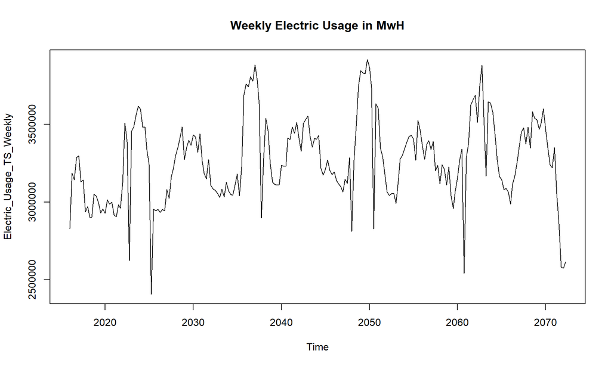

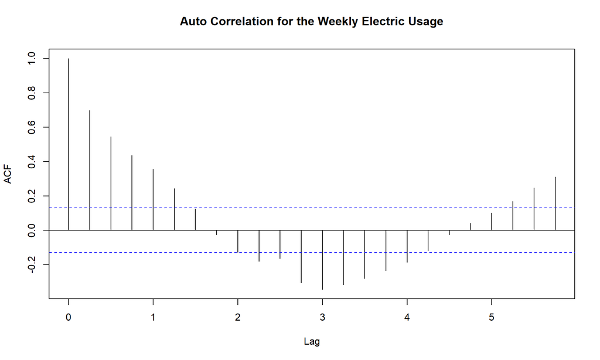

```r
ts.plot(Electric_Usage_TS_Weekly,main="Weekly Electric Usage in MwH")
acf(Electric_Usage_TS_Weekly,main="Auto Correlation for the Weekly Electric Usage")
```

Figure 13&14: Series & Auto-Correlation Plots for Weekly Frequency Comments: It is not easy to read a reversion to previous values from the acf or the plot because of previously mentioned issues. To read it right, first the data should be brought into 28-months or a fractional value for the frequency should be used. However, this problem will not be further analyzed.

Decomposing the series on weeks

```r
Electric_Usage_TS_Weekly_Multiplicative<-decompose(Electric_Usage_TS_Weekly,type="multiplicative")
Electric_Usage_TS_Weekly_Additive<-decompose(Electric_Usage_TS_Weekly,type="additive")
```

Plotting:

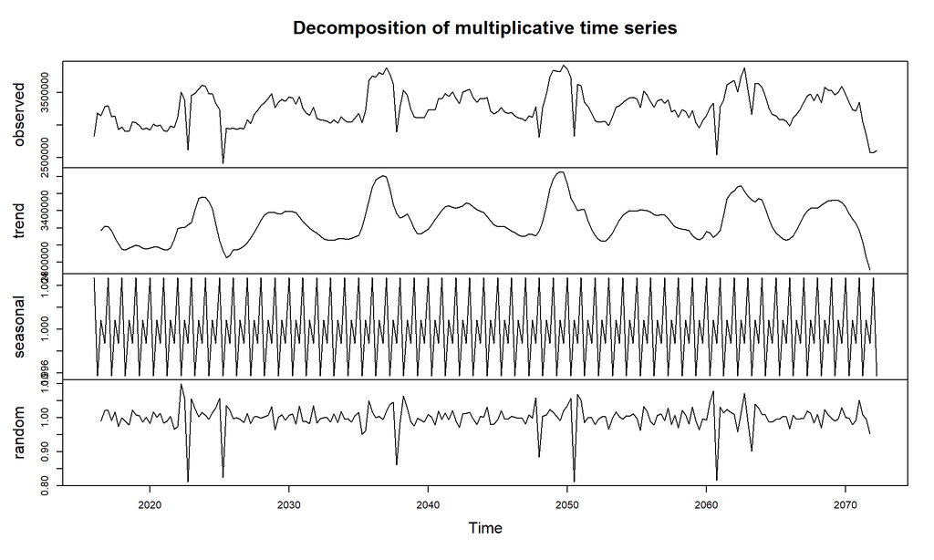

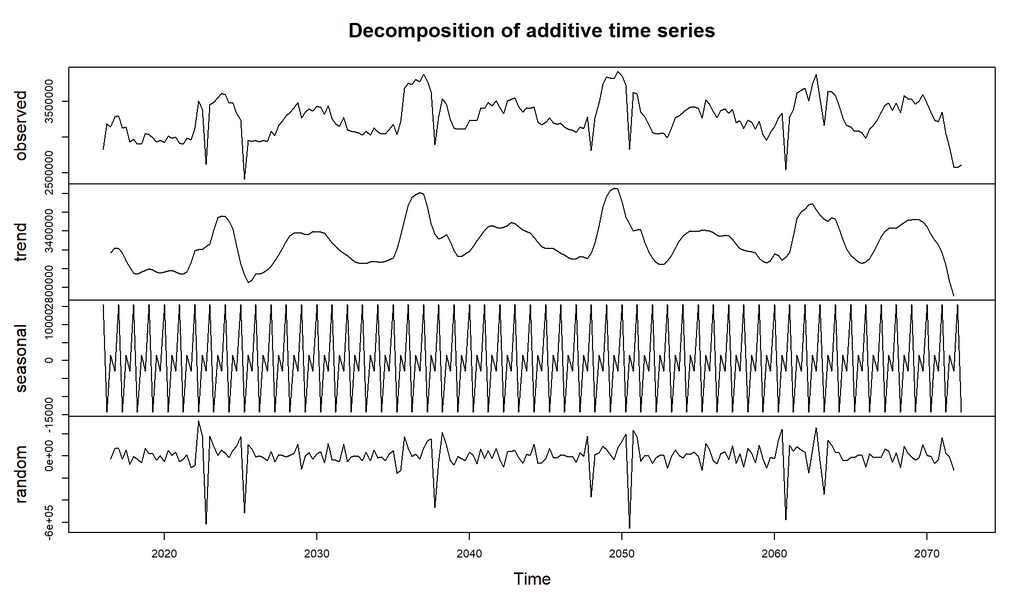

```r
plot(Electric_Usage_TS_Weekly_Multiplicative)
plot(Electric_Usage_TS_Weekly_Additive)
```

Checking Randomness

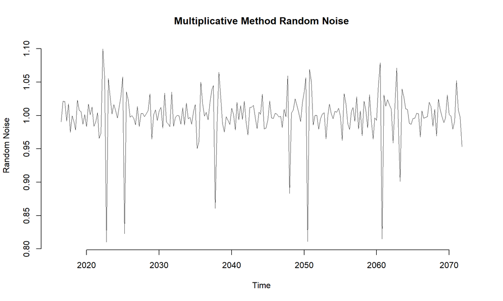

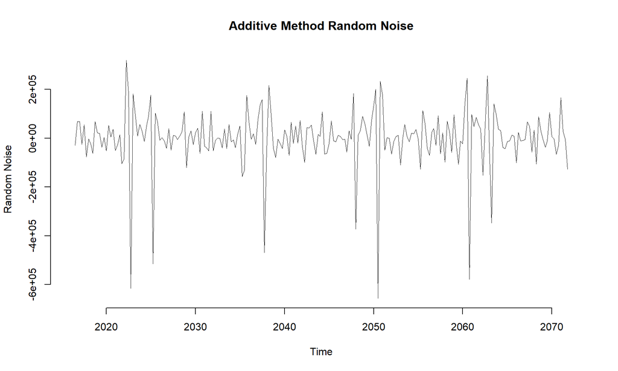

```r
plot(Electric_Usage_TS_Weekly_Multiplicative$random,
     frame=FALSE,
     col="black",
     lwd=0.1,
     main="Multiplicative Method Random Noise",
     ylab= "Random Noise",
     xlab= "Time")
plot(Electric_Usage_TS_Weekly_Additive$random,
     frame=FALSE,
     col="black",
     lwd=0.1,
     main="Additive Method Random Noise",
     ylab= "Random Noise",
     xlab= "Time")
```

Fİgure 17&18: Weekly Multiplicative and Additive Data Randomness Comments : Additive method again shows a better fit.

Converting Monthly - The last conversion is the last conversion to be made since converting yearly when we only have 4 years does not yield any meaningful statistical results.

```r
eu_monthly<-endpoints(Electric_Usage_XTS_Hourly,on="months")
Electric_Usage_XTS_Monthly<-period.apply(Electric_Usage_XTS_Hourly,INDEX=eu_monthly,FUN=mean)
periodicity(Electric_Usage_XTS_Monthly)
```

```
## Monthly periodicity from 2016-01-31 to 2020-04-26
```

Converting to Time Series object, frequency equals to 12 since we have 12 observations on mean per year.

```r
Electric_Usage_TS_Monthly<-ts(Electric_Usage_XTS_Monthly,start=c(2016,1),frequency = 12)
length(Electric_Usage_TS_Monthly)
```

```
## [1] 52
```

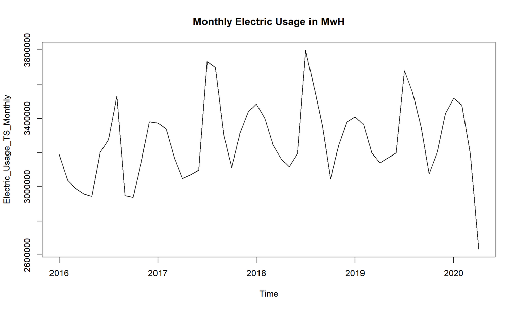

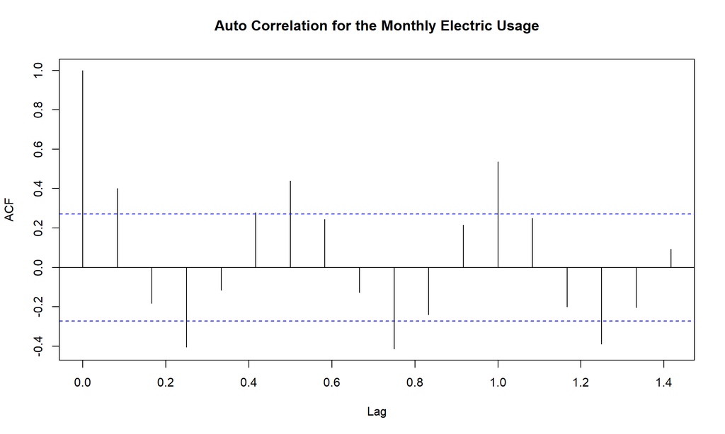

```r
ts.plot(Electric_Usage_TS_Monthly,main="Monthly Electric Usage in MwH")
acf(Electric_Usage_TS_Monthly,main="Auto Correlation for the Monthly Electric Usage")
```

Figure 19&20: Series & Auto-Correlation Plots for Monthly Frequency Comments: As the data amount keeps decreasing we are having less and less meaningful deductions from the data. Also the problem mentioned before is also present in this case. However ACF values keeps getting better since we have already eliminated the correlation in the daily and weekly data by transforming the time series object on months, We are only looking at the means from certain months and not the full data.

Decomposing:

```r
Electric_Usage_TS_Monthly_Multiplicative<-decompose(Electric_Usage_TS_Monthly,type="multiplicative")
Electric_Usage_TS_Monthly_Additive<-decompose(Electric_Usage_TS_Monthly,type="additive")
```

Plotting

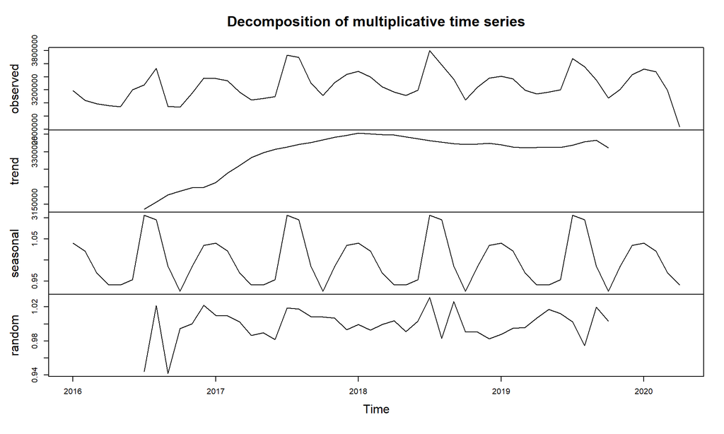

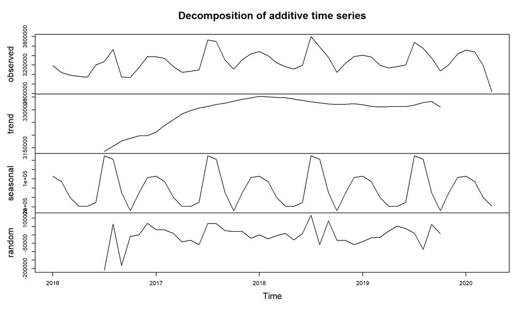

```r
plot(Electric_Usage_TS_Monthly_Multiplicative)
plot(Electric_Usage_TS_Monthly_Additive)
```

Also, looking at the randomness:

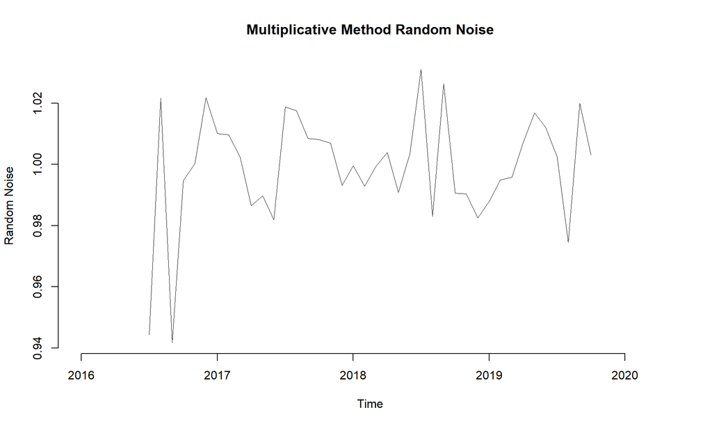

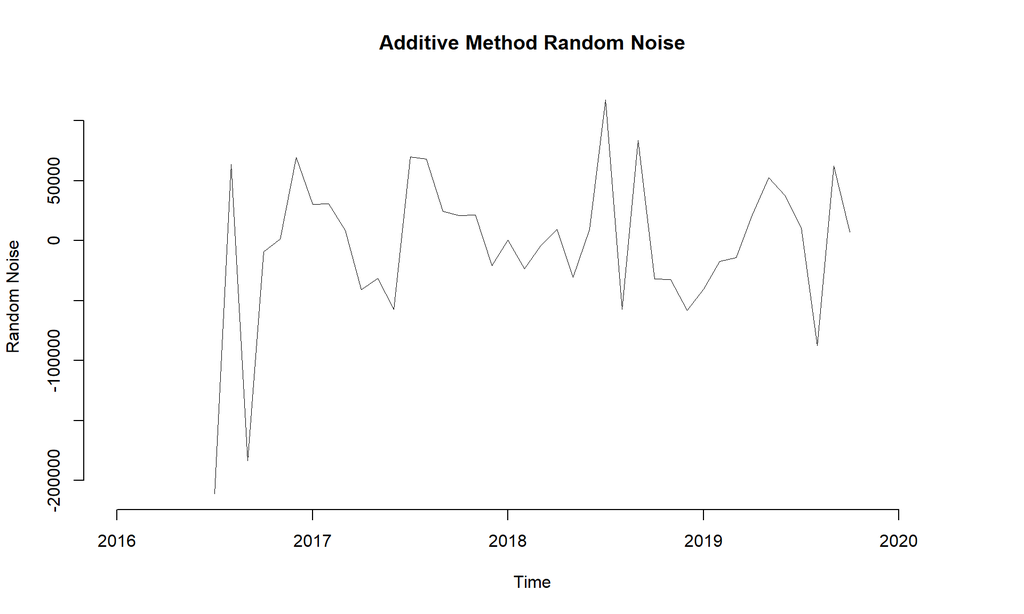

```r
plot(Electric_Usage_TS_Monthly_Multiplicative$random,
     frame=FALSE,
     col="black",
     lwd=0.1,
     main="Multiplicative Method Random Noise",
     ylab= "Random Noise",
     xlab= "Time")
plot(Electric_Usage_TS_Monthly_Additive$random,
     frame=FALSE,
     col="black",
     lwd=0.1,
     main="Additive Method Random Noise",
     ylab= "Random Noise",
     xlab= "Time")
```

Figure 23&24: Monthly Multiplicative and Additive Data Randomness Comments: These graphs don not exhibit any different properties than the ones before however it proves hard to read an obvious reduction or reversion on the mean since there is less datapoints.

Since we are - at the end - trying to forecast 24 steps ahead for the data we have, we must first bring it into a form in which we can successfully build a model, as far as we have seen the original data is not “stationary” and this property doesnt allow for easy forecasting, first we need to bring the data to a stationary state in which mean and variance does not change,

From the decomposition graphs, it is obvious that we have a seasonality both on hours and days, therefore we have 168 hours of repeating. Working on this multiple seasonality proves a difficulty, either we need to build a model in which we can remove both daily and weekly seasonality together using a different time series model like stl and tbats or simply deseasonlize and detrend the hourly series with a frequency of 168

So far, we have seen a clear trend and a reversion to the previous levels in 24 hours and also 7 days. Therfore we will use a model incorporating both these trends in the same frequency,

Converting the hourly data into a time seres with frequency=168

```r
Electric_Usage_TS_168<-ts(Electric_Usage_XTS_Hourly,start=c(2016,1),frequency =168)
length(Electric_Usage_TS_168)
```

```
## [1] 37848
```

Plotting the data

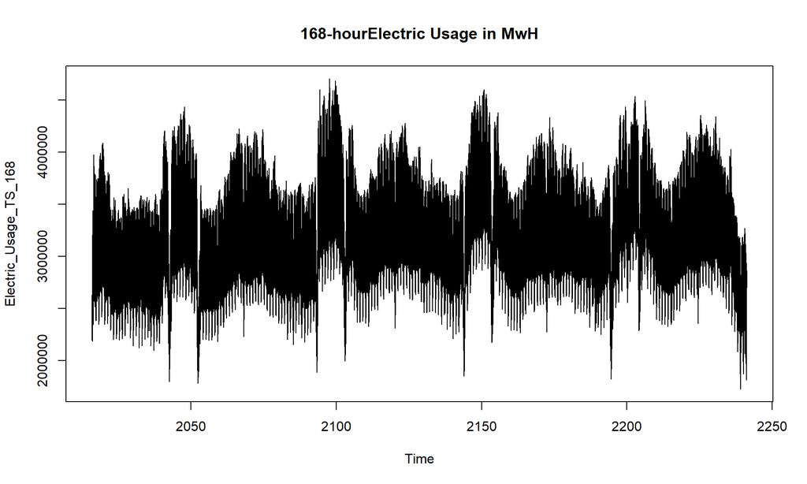

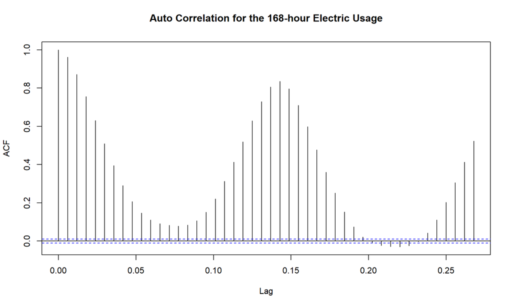

```r
ts.plot(Electric_Usage_TS_168,main="168-hourElectric Usage in MwH" )
acf(Electric_Usage_TS_168,main="Auto Correlation for the 168-hour Electric Usage")
```

Figure 24&25: Series & Auto-Correlation Plots for 168-hour Frequency Comments: The series does not show any drag, therefore log transform will not be made. Also the trends are exhibitied. Thefore, before forecasting these trends will be removed to build a stationary time series. As “Additive” Method proved the better choice and fit,analysis will be done on this method

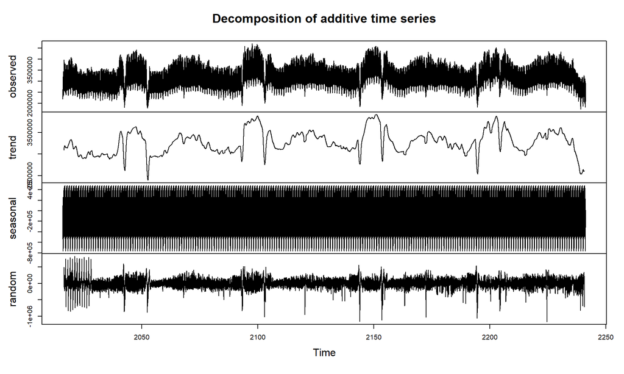

```r
Electric_Usage_TS_168_Additive<-decompose(Electric_Usage_TS_168,type="additive")
plot(Electric_Usage_TS_168_Additive)
```

Figure 26: Additive Method 169-hour Decomposition Comments: Trend is visible, also randomness has a quick reversion to the mean with no drag and a specific variance change, further analysis can be made.

Deseasonalizing the series, since additive method is used, Seasonality part of the model will be substracted from the data

```r
Electric_Usage_TS_168_Additive_Deseasonalized<-Electric_Usage_TS_168-Electric_Usage_TS_168_Additive$seasonal
```

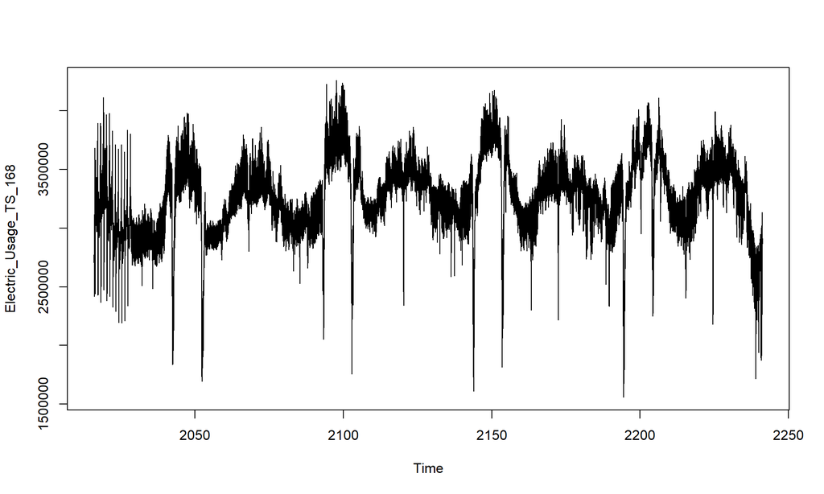

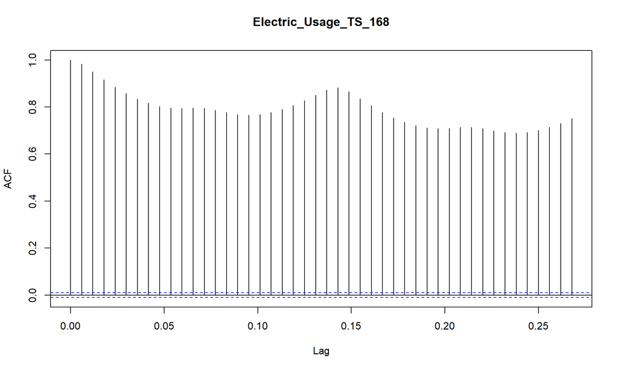

```r
plot(Electric_Usage_TS_168_Additive_Deseasonalized)
acf(Electric_Usage_TS_168_Additive_Deseasonalized)
```

Figure 27&28: Deseasonalized data and ACF Comments: ACF shows little seasonality ( because we have not removed monthly or yearly seasonality) and also trend becomes more obvious.

Detrending the series, since additive model is used Trend part of the model will be substracted from the data

```r
Electric_Usage_TS_168_Additive_Deseasonalized_Detrended<-Electric_Usage_TS_168_Additive_Deseasonalized-Electric_Usage_TS_168_Additive$trend
```

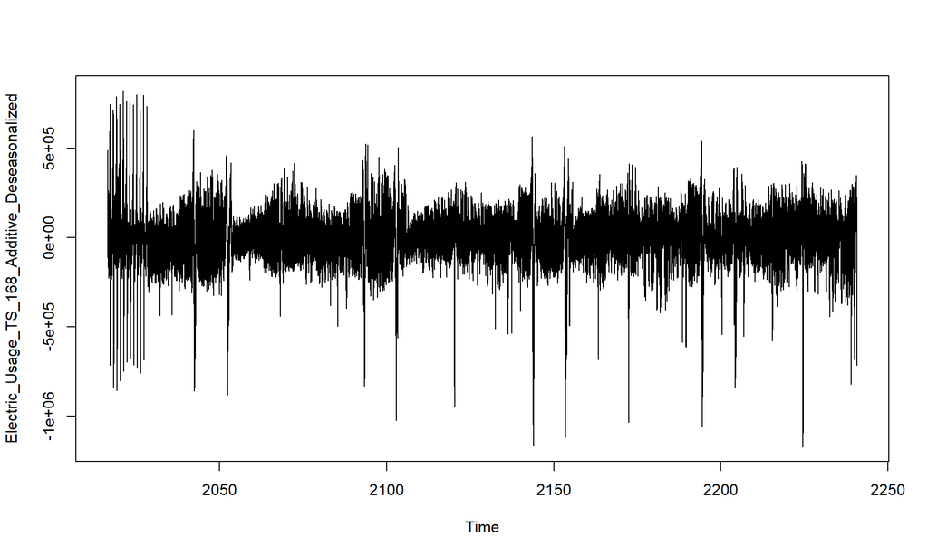

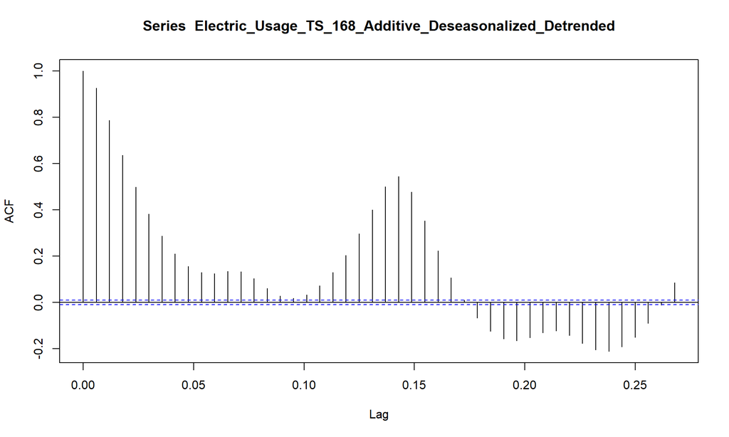

```r
plot(Electric_Usage_TS_168_Additive_Deseasonalized_Detrended)
acf(Electric_Usage_TS_168_Additive_Deseasonalized_Detrended,na.action = na.omit)
```

Figure 29&30: Deseasonalized and Detrended data and ACF Comments: Correlation becomes lower but this is as far as we can remove the seasonality and trend without differencing the data on lags. This will not be performed since it complicates the arima method in forecasting beyond the scope of my report. Also, the plot on the left shows a stationary-like variable therefore we can conclude that this may prove to be a good forecasting baseline.

Fitting Models, Trying out the AR and MA models on the data we have brought into a stationary-like

```r
Model_1<-arima(Electric_Usage_TS_168_Additive_Deseasonalized_Detrended, order=c(1,0,0))
AIC(Model_1)
```

```
## [1] 931534.8
```

```r
BIC(Model_1)
```

```
## [1] 931560.4
```

```r
Model_2<-arima(Electric_Usage_TS_168_Additive_Deseasonalized_Detrended, order=c(0,0,1))
AIC(Model_2)
```

```
## [1] 963564.2
```

```r
BIC(Model_2)
```

```
## [1] 963589.8
```

First one is better, therefore Auto-Regressive Model will be Modelled with the data

Modelling the data on AR, also calculating the fitted model for later use

```r
Final_Model<-arima(Electric_Usage_TS_168_Additive_Deseasonalized_Detrended, order=c(1,0,0))
Fitted_Model <- Electric_Usage_TS_168 - residuals(Final_Model)
```

Fitting the Models on the actual usage rate with 168-hour use period.

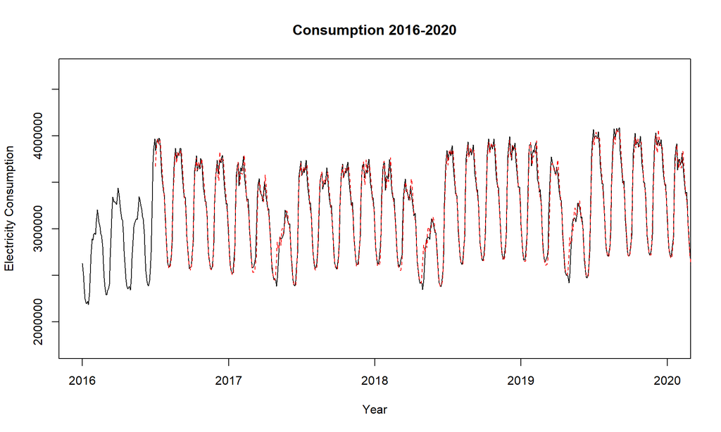

```r
ts.plot(Electric_Usage_TS_168, xlab = "Year", ylab = "Electricity Consumption",main="Consumption 2016-2020",xlim=c(2016,2020))
points(Fitted_Model, type = "l", col = 2, lty = 2)
```

Figure 29: Fitted Model & 168-hour Electric Usage  
Comments: Fitted Model appears to be a good fit to the model

Forecasting the future 24 hours

```r
Final_Model_Forecast <- predict(Final_Model, n.ahead = 24)$pred
Final_Model_Forecast_SE<-predict(Final_Model, n.ahead = 24)$se
print(as.data.frame(Final_Model_Forecast))
```

```
##               x
## 1  -811.2149064
## 2  -735.2280383
## 3  -664.7952584
## 4  -599.5106033
## 5  -538.9977823
## 6  -482.9080092
## 7  -430.9179911
## 8  -382.7280658
## 9  -338.0604740
## 10 -296.6577589
## 11 -258.2812815
## 12 -222.7098460
## 13 -189.7384241
## 14 -159.1769737
## 15 -130.8493433
## 16 -104.5922570
## 17  -80.2543731
## 18  -57.6954117
## 19  -36.7853466
## 20  -17.4036554
## 21    0.5613749
## 22   17.2132920
## 23   32.6480749
## 24   46.9546872
```

Table 1: Forecasted Values  
Comments: Values seems a bit off since we have already removed the values for the trend and seasonality, we must add this back to the forecasted values and normalize it.

Taking the trend values from the last non-NA value in the decomposition

```r
Trend_Values<-as.numeric(tail(na.omit(Electric_Usage_TS_168_Additive$trend),1)) #2614387
Trend_Values # Just one value actually
```

```
## [1] 2614387
```

Taking the Forecast Values from the Model Forecast

```r
Forecast_Values<-as.numeric(Final_Model_Forecast)
```

```r
Figure_Values<-head(Electric_Usage_TS_168_Additive$figure,24)
```

Adding all the values together and coming up with the actual or realized forecasts

```r
Realized_Forecast<-2614387+Forecast_Values+Figure_Values
```

Also, we need to find the upper and lower bound for the Realized Standard Error for these forecasts. It is done in the same way with z values taken as fractions 1.96

```r
SE_Lower_Bound<-Final_Model_Forecast-1.96*Final_Model_Forecast_SE

SE_Lower_Bound<-SE_Lower_Bound+2614387+Figure_Values


SE_Upper_Bound<-Final_Model_Forecast+1.96*Final_Model_Forecast_SE ## Upper Bound estimate on the forecast
SE_Upper_Bound<-SE_Upper_Bound+2614387+Figure_Values ## Actual Realized Upper Bound estimate on the forecast
```

Calculating the mean for the last 24 actual values to be a benchmark for the forecasted values, also last 24 values could have been taken directly but is not considered neccessary.

```r
mean(tail(Electric_Usage_Data$`Usage(MwH)`,24)) # Will be used for plotting
```

```
## [1] 2331767
```

It is not possible to see 24 hour predictions on the given hourly setting - too much data - , therefore I will only plot the data with the mean of the last observations to see the trend and also bounds with the historic mean.

[figure not shown]

```r
plot(Realized_Forecast, cex=1.7, pch=19,frame=FALSE,main="24 Hour Forecast Values in MwH", ylab="Energy Use", xlab="Time of Day", col="blue")
abline(h=2331767,col="red")
points(SE_Lower_Bound,type = "l", col = 2, lty = 2)
```

Looking at the Bounds with Realized Forecasts.

```r
Forecast_Data<-cbind(SE_Lower_Bound,Realized_Forecast,SE_Upper_Bound)

Forecast_Data<-as.data.frame(Forecast_Data)
head(Forecast_Data)
```

```
##   SE_Lower_Bound Realized_Forecast SE_Upper_Bound
## 1        2209512           2504616        2799720
## 2        2047046           2342151        2637255
## 3        1928213           2223317        2518421
## 4        1848622           2143727        2438831
## 5        1813137           2108242        2403346
## 6        1790877           2085981        2381086
```

Table 2: Lower, Upper Bounds and Realized Forecast, Data Frame  
Comments: Model is fairly successful in remaining close to bounds.

```r
# Setting the dates for the forecasted period
dates<-seq(as.POSIXct("2020-04-27 00:00:00"), as.POSIXct("2020-04-27 23:00:00"), by="hour")

#Converting to XTS for better manipulation
Forecast_Data_XTS<-xts(Forecast_Data,order.by = dates)
head(Forecast_Data_XTS)
```

```
##                     SE_Lower_Bound Realized_Forecast SE_Upper_Bound
## 2020-04-27 00:00:00        2209512           2504616        2799720
## 2020-04-27 01:00:00        2047046           2342151        2637255
## 2020-04-27 02:00:00        1928213           2223317        2518421
## 2020-04-27 03:00:00        1848622           2143727        2438831
## 2020-04-27 04:00:00        1813137           2108242        2403346
## 2020-04-27 05:00:00        1790877           2085981        2381086
```

Table 3: Lower, Upper Bounds and Realized Forecast, XTS Object Comments: Dates and Hours added

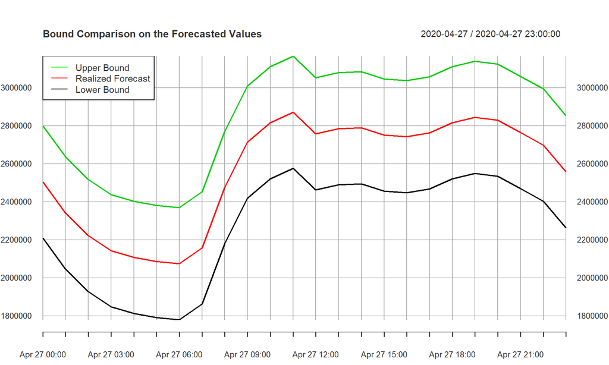

Figure 31: Forecasted Values and Bounds Comments: A better view of the data with the hours added.

As an extra and a more accurate - as I believe - method: Forecasting Using stlm and mtsm and a train - test data.

Using Multiple Seasonality & Trends Removal with stlm and mtsm

Get the data into a train object

Uses hourly data from daily natural period therefore frequency should be 24, We will use the XTS object directly here without any changes to the original data.

```r
Electric_Usage_Forecast_1_Train<-Electric_Usage_XTS_Hourly %>% ts(freq= 24)
```

Decomposing the data on the given settings

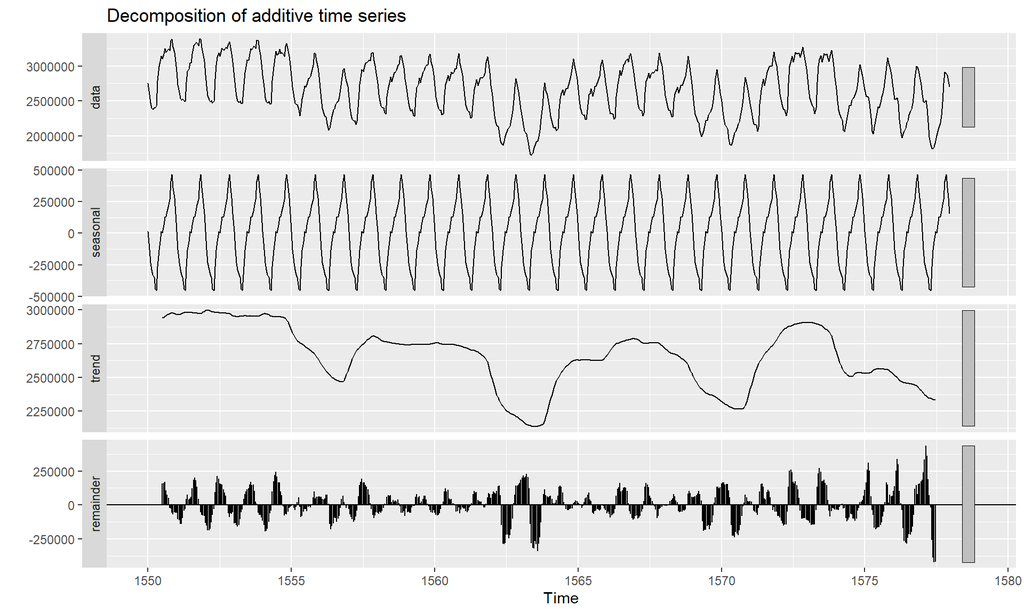

```r
Electric_Usage_Forecast_1_Train %>%
        tail(24*7*4) %>%
        decompose() %>%
        autoplot()
```

Figure 32: Decomposition on the Daily Format Comments: Denser trends can be seen from the graph with tail equaling 24*7*4

Trends are daily and weekly, we will seperate these trends into two parts with a mtsm object

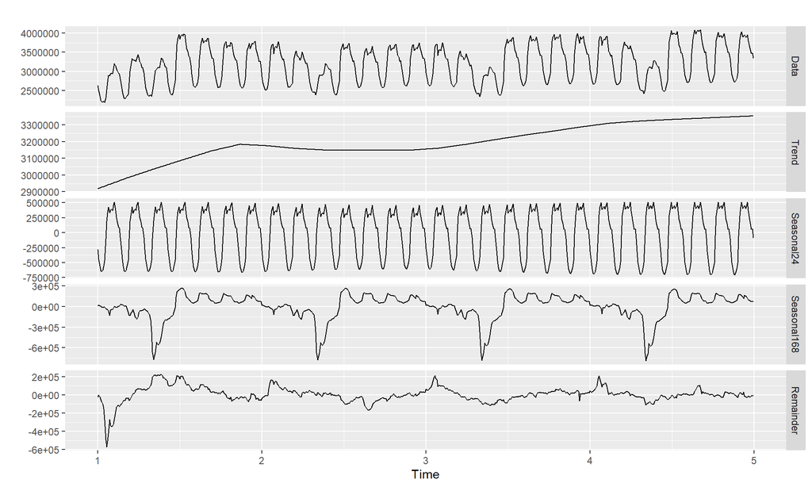

```r
Electric_Usage_Forecast_1_msts<-Electric_Usage_XTS_Hourly %>% msts( seasonal.periods = c(24, 24*7))
Electric_Usage_Forecast_1_msts %>% head(  24 *7 *4 ) %>% mstl() %>% autoplot()
```

Seperating the data into test & train parts before forecasting

```r
Electric_Usage_Forecast_1_Train_msts_train <- head(Electric_Usage_Forecast_1_msts, length(Electric_Usage_Forecast_1_msts) - 24*7*12)
Electric_Usage_Forecast_1_Train_msts_test <- tail(Electric_Usage_Forecast_1_msts,  24*7*12)
```

Subsetting to a recent period (To plot the data better)

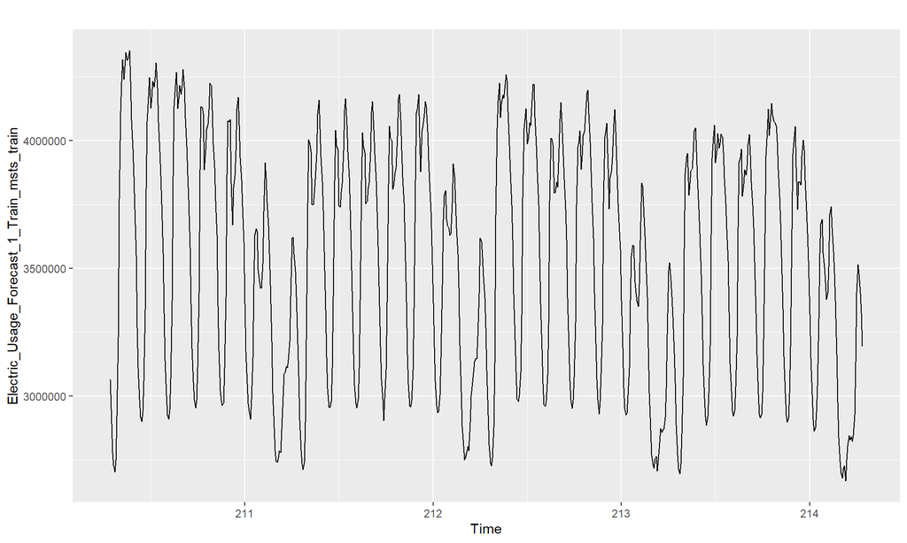

```r
Electric_Usage_Forecast_1_Train_msts_train <- tail(Electric_Usage_Forecast_1_Train_msts_train, 24*7*4)
autoplot(Electric_Usage_Forecast_1_Train_msts_train)
```

Figure 34: Subsetted Data for Forecast Fitting Comments: It is easier to show the forecasted values fitting on the actual model using this method.

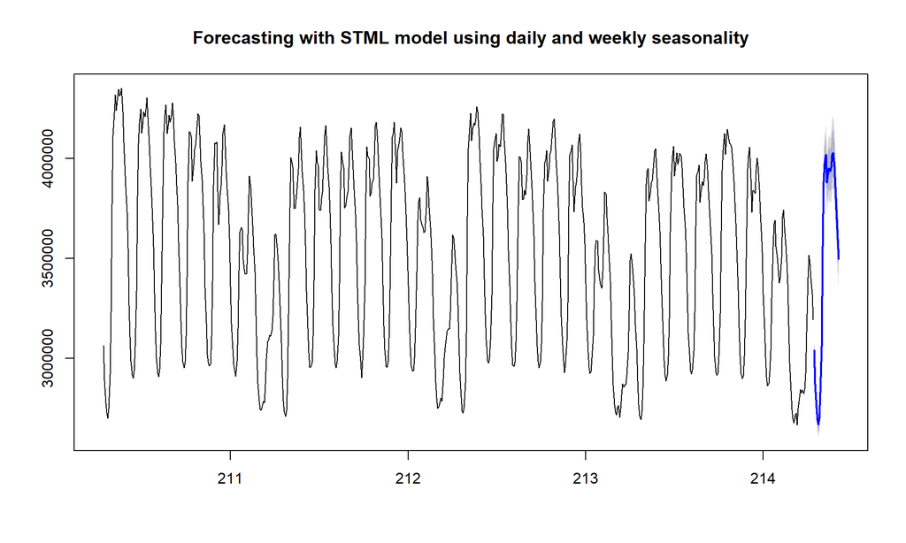

```r
Forecast_1_Model <- Electric_Usage_Forecast_1_Train_msts_train %>%
        stlm(lambda = 0) %>%
        forecast(h = 24)
plot(Forecast_1_Model, main="Forecasting with STML model using daily and weekly seasonality")
```

Figure 35: Subsetted Period and Forecasted period fitted.  
Comments: Model is fairly successful in capturing the spike in the data and also has a high probability of remaining between error bounds.

```r
Forecast_1_Model_Data_Frame<-as.data.frame(Forecast_1_Model)

dates<-seq(as.POSIXct("2020-04-27 00:00:00"), as.POSIXct("2020-04-27 23:00:00"), by="hour")

Forecast_Data_XTS_stlm<-xts(Forecast_1_Model_Data_Frame,order.by = dates)

print(as.data.frame(Forecast_Data_XTS_stlm))
```

```
##                     Point Forecast   Lo 80   Hi 80   Lo 95   Hi 95
## 2020-04-27 00:00:00        3041015 3020452 3061718 3009623 3072735
## 2020-04-27 01:00:00        2871518 2844099 2899203 2829690 2913966
## 2020-04-27 02:00:00        2752429 2720275 2784964 2703406 2802342
## 2020-04-27 03:00:00        2690452 2654193 2727207 2635196 2746866
## 2020-04-27 04:00:00        2669915 2629717 2710727 2608684 2732583
## 2020-04-27 05:00:00        2701742 2657215 2747014 2633942 2771287
## 2020-04-27 06:00:00        2829332 2779000 2880575 2752719 2908077
## 2020-04-27 07:00:00        3060971 3002794 3120274 2972446 3152131
## 2020-04-27 08:00:00        3561908 3490147 3635146 3452745 3674523
## 2020-04-27 09:00:00        3884408 3801961 3968644 3759027 4013972
## 2020-04-27 10:00:00        3973218 3884816 4063632 3838817 4112324
## 2020-04-27 11:00:00        4018380 3925044 4113936 3876516 4165436
## 2020-04-27 12:00:00        3880477 3786709 3976567 3737991 4028394
## 2020-04-27 13:00:00        3920149 3821891 4020932 3770877 4075329
## 2020-04-27 14:00:00        3950443 3847996 4055617 3794844 4112422
## 2020-04-27 15:00:00        3937325 3831915 4045635 3777262 4104172
## 2020-04-27 16:00:00        3955915 3846793 4068132 3790251 4128819
## 2020-04-27 17:00:00        4017504 3903517 4134820 3844491 4198304
## 2020-04-27 18:00:00        4027999 3910628 4148893 3849887 4214352
## 2020-04-27 19:00:00        3959414 3841090 4081384 3779891 4147464
## 2020-04-27 20:00:00        3854529 3736538 3976245 3675547 4042226
## 2020-04-27 21:00:00        3745305 3628003 3866400 3567401 3932081
## 2020-04-27 22:00:00        3645069 3528382 3765615 3468131 3831034
## 2020-04-27 23:00:00        3497902 3383557 3616111 3324548 3680295
```

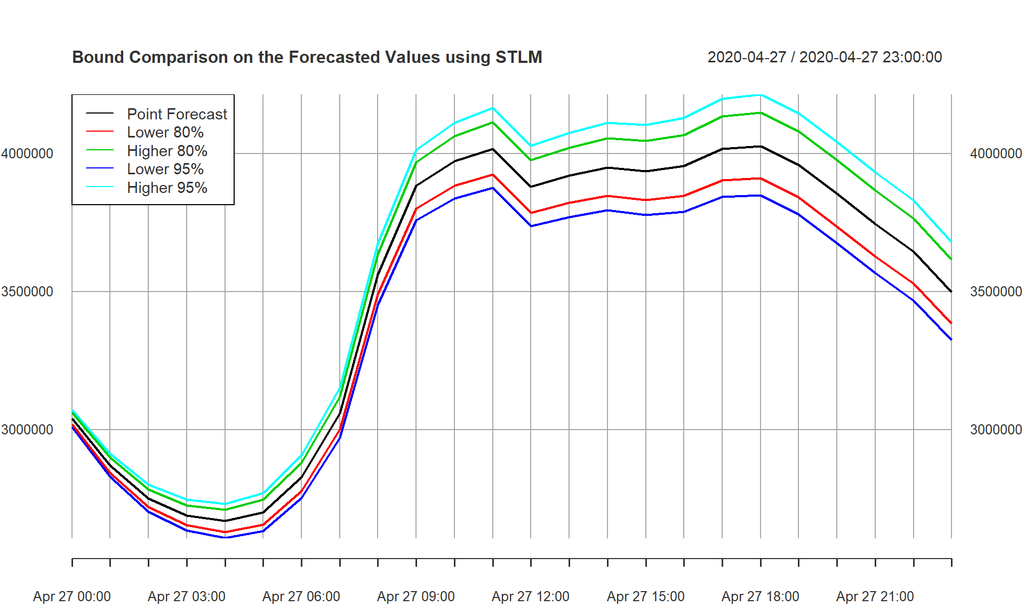

Results reached are given as the graphs are plotted, However, it is useful to give a brief conclusion of the analysis, Firstly: The data is read and converted to hourly(natural observation period - no manipulation is performed -), daily, weekly and monthly periods, the last 3 period conversions are done by converting the data with an xts object and aggregating the values by mean on the endpoints of the given period. ACF’s and also MwH usage graphs are examined. Also, it is decided that an “Additive” method should be used in decomposing the data for further analysis.A 168 hour periodicity is agreed upon as was stated in the homework description.

After this decision, the data is seperated into the 168-hour frequency, deaseasonalized and detrended on this frequency. - No log transformation is used - The series is brought into a stationary-like series with a constant mean and variance. AR and MA models are fitted, AR model is decided to be better based on the AIC and BIC Values. A model is fitted and residuals are calculated.

Finally, After the model is fitted, prediction based on the previous values are made, these values are normalized to Actual or Realized forecast values using the trend and figure parts of the decomposition. Forecast values are normalized, Standard Error Values are also normalized. Hourly forecasts are made and plotted. Comments are made with the graphs for better understanding.

R Script is mostly the same but some last minute changes are done directly from the RMD file, therefore it may be missing some code. All the code is already present in this file and can be followed with ease.

Here’s my R Script: https://github.com/BU-IE-360/spring20-esatcanli/blob/master/files/HW23%20R%20Script.R